# ipsRdbs: Introduction to Probability, Statistics and R for Data-Based Sciences

```r
 anova(possum.lm2)
```

```
#> Analysis of Variance Table
#>
#> Response: y
#>           Df  Sum Sq Mean Sq F value    Pr(>F)
#> z          1 12.0139 12.0139  128.35 < 2.2e-16 ***
#> Residuals 99  9.2665  0.0936
#> ---
#> Signif. codes:  0 '***' 0.001 '**' 0.01 '*' 0.05 '.' 0.1 ' ' 1
```

```r
 # Include both location and length but no interaction
 possum.lm3 <-  lm(y~x+z, data=localpossum)
 summary(possum.lm3)
```

```
#>
#> Call:
#> lm(formula = y ~ x + z, data = localpossum)
#>
#> Residuals:
#>      Min       1Q   Median       3Q      Max
#> -0.67242 -0.19970  0.01845  0.17516  0.78209
#>
#> Coefficients:
#>              Estimate Std. Error t value Pr(>|t|)
#> (Intercept) -3.390403   0.816320  -4.153 7.27e-05 ***
#> x2           0.057028   0.117868   0.484  0.62964
#> x3           0.100261   0.119312   0.840  0.40288
#> x4           0.152418   0.128260   1.188  0.23772
#> x5          -0.176672   0.096536  -1.830  0.07044 .
#> x6          -0.310958   0.104334  -2.980  0.00367 **
#> x7          -0.161791   0.092289  -1.753  0.08288 .
#> z            0.072719   0.009083   8.006 3.29e-12 ***
#> ---
#> Signif. codes:  0 '***' 0.001 '**' 0.01 '*' 0.05 '.' 0.1 ' ' 1
#>
#> Residual standard error: 0.2845 on 93 degrees of freedom
#> Multiple R-squared:  0.6463, Adjusted R-squared:  0.6197
#> F-statistic: 24.28 on 7 and 93 DF,  p-value: < 2.2e-16
```

```r
 anova(possum.lm3)
```

```
#> Analysis of Variance Table
#>
#> Response: y
#>           Df Sum Sq Mean Sq F value    Pr(>F)
#> x          6 8.5667  1.4278  17.643 1.521e-13 ***
#> z          1 5.1876  5.1876  64.102 3.287e-12 ***
#> Residuals 93 7.5262  0.0809
#> ---
#> Signif. codes:  0 '***' 0.001 '**' 0.01 '*' 0.05 '.' 0.1 ' ' 1
```

```r
 # Include interaction effect
 possum.lm4 <-  lm(y~x+z+x:z, data=localpossum)
 summary(possum.lm4)
```

```
#>
#> Call:
#> lm(formula = y ~ x + z + x:z, data = localpossum)
#>
#> Residuals:
#>      Min       1Q   Median       3Q      Max
#> -0.67953 -0.15793  0.01999  0.14591  0.78255
#>
#> Coefficients:
#>               Estimate Std. Error t value Pr(>|t|)
#> (Intercept) -3.5842639  1.5008154  -2.388   0.0191 *
#> x2           0.3283443  2.3839136   0.138   0.8908
#> x3           6.0527549  3.3898871   1.786   0.0777 .
#> x4          -5.9670098  4.5482536  -1.312   0.1930
#> x5          -2.4035332  2.7983463  -0.859   0.3927
#> x6           0.8984502  2.4135144   0.372   0.7106
#> x7          -0.1263706  2.4142962  -0.052   0.9584
#> z            0.0748795  0.0167202   4.478 2.27e-05 ***
#> x2:z        -0.0031036  0.0280484  -0.111   0.9121
#> x3:z        -0.0675469  0.0383301  -1.762   0.0815 .
#> x4:z         0.0663129  0.0494622   1.341   0.1835
#> x5:z         0.0256881  0.0318912   0.805   0.4227
#> x6:z        -0.0141738  0.0279034  -0.508   0.6128
#> x7:z        -0.0003129  0.0276672  -0.011   0.9910
#> ---
#> Signif. codes:  0 '***' 0.001 '**' 0.01 '*' 0.05 '.' 0.1 ' ' 1
#>
#> Residual standard error: 0.2828 on 87 degrees of freedom
#> Multiple R-squared:  0.6731, Adjusted R-squared:  0.6243
#> F-statistic: 13.78 on 13 and 87 DF,  p-value: 4.8e-16
```

```r
 anova(possum.lm4)
```

```
#> Analysis of Variance Table
#>
#> Response: y
#>           Df Sum Sq Mean Sq F value    Pr(>F)
#> x          6 8.5667  1.4278 17.8561 2.194e-13 ***
#> z          1 5.1876  5.1876 64.8768 3.833e-12 ***
#> x:z        6 0.5696  0.0949  1.1873    0.3206
#> Residuals 87 6.9565  0.0800
#> ---
#> Signif. codes:  0 '***' 0.001 '**' 0.01 '*' 0.05 '.' 0.1 ' ' 1
```

```r
 anova(possum.lm2, possum.lm3)
```

```
#> Analysis of Variance Table
#>
#> Model 1: y ~ z
#> Model 2: y ~ x + z
#>   Res.Df    RSS Df Sum of Sq      F   Pr(>F)
#> 1     99 9.2665
#> 2     93 7.5262  6    1.7404 3.5842 0.003065 **
#> ---
#> Signif. codes:  0 '***' 0.001 '**' 0.01 '*' 0.05 '.' 0.1 ' ' 1
```

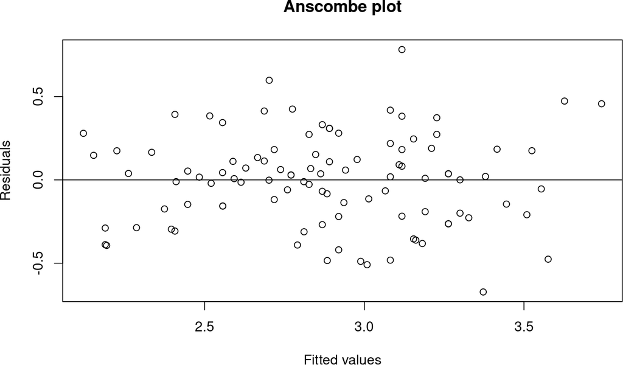

```r
 #Check the diagnostics for M3
 plot(possum.lm3$fit, possum.lm3$res,xlab="Fitted values",ylab="Residuals",
 main="Anscombe plot")
 abline(h=0)
```

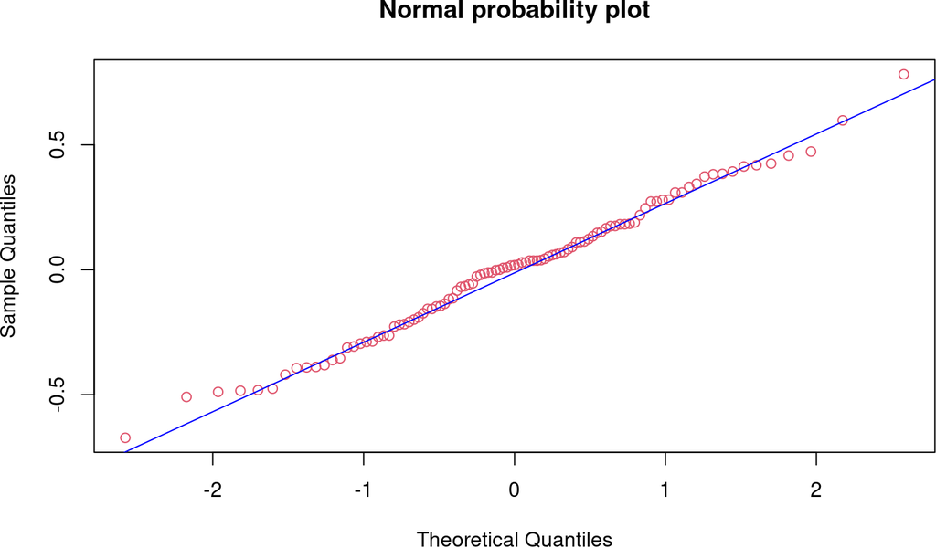

```r
 qqnorm(possum.lm3$res,main="Normal probability plot", col=2)
 qqline(possum.lm3$res, col="blue")
```

```r
 rm(localpossum)
 rm(poss)
```

## 2.13 `puffin` : Nesting habits of puffins in Newfoundland

This object contains data regarding nesting habits of common puffin. Source: Nettleship (1972). (Nettleship 1972) This data set has been used to illustrate multiple linear regression modeling in Chapter 18 of the book Sahu (2024).

```r
head(puffin)
```

```
#>   Nesting_Frequency Grass_Cover Mean_Soil_Depth Slope_Angle Distance_from_Edge
#> 1                 0          15            27.8           8                 45
#> 2                 0           0            41.9           8                 54
#> 3                 0          20            36.8           5                 60
#> 4                 0          30            37.7           8                 42
#> 5                 0          75            45.5           5                 48
#> 6                 0          15            51.4           8                 54
```

```r
dim(puffin)
```

```
#> [1] 38  5
```

```r
summary(puffin)
```

```
#>  Nesting_Frequency  Grass_Cover    Mean_Soil_Depth  Slope_Angle    Distance_from_Edge
#>  Min.   : 0.000    Min.   : 0.00   Min.   :24.30   Min.   : 2.00   Min.   : 3.00
#>  1st Qu.: 0.000    1st Qu.:40.00   1st Qu.:32.75   1st Qu.: 7.25   1st Qu.:18.00
#>  Median : 7.500    Median :60.00   Median :37.40   Median :10.00   Median :30.00
#>  Mean   : 7.684    Mean   :56.45   Mean   :37.72   Mean   :15.00   Mean   :30.39
#>  3rd Qu.:12.750    3rd Qu.:80.00   3rd Qu.:42.83   3rd Qu.:21.25   3rd Qu.:44.25
#>  Max.   :25.000    Max.   :95.00   Max.   :51.40   Max.   :38.00   Max.   :60.00
```

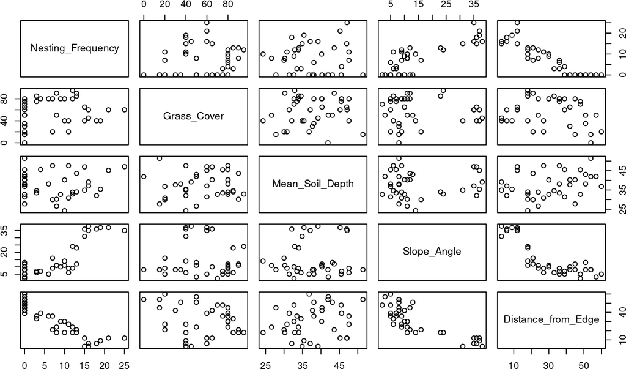

```r
pairs(puffin)
```

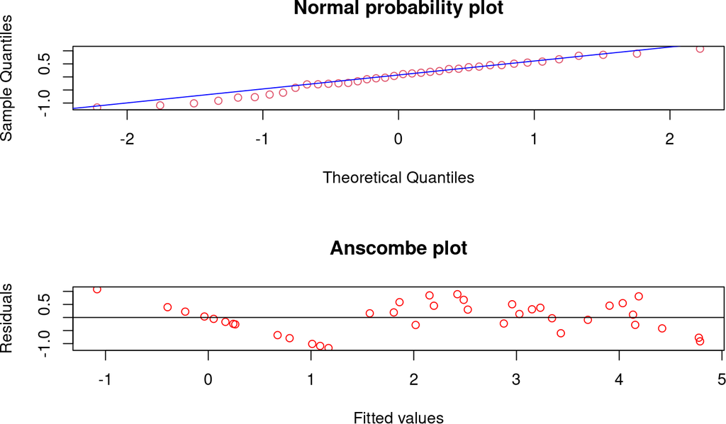

```r
puffin$sqrtfreq <- sqrt(puffin$Nesting_Frequency)
puff.sqlm <- lm(sqrtfreq~ Grass_Cover + Mean_Soil_Depth + Slope_Angle
+Distance_from_Edge, data=puffin)
old.par <- par(no.readonly = TRUE)
par(mfrow=c(2,1))
qqnorm(puff.sqlm$res,main="Normal probability plot", col=2)
qqline(puff.sqlm$res, col="blue")
plot(puff.sqlm$fit, puff.sqlm$res,xlab="Fitted values",ylab="Residuals",
main="Anscombe plot", col="red")
abline(h=0)
```

```r
summary(puff.sqlm)
```

```
#>
#> Call:
#> lm(formula = sqrtfreq ~ Grass_Cover + Mean_Soil_Depth + Slope_Angle +
#>     Distance_from_Edge, data = puffin)
#>
#> Residuals:
#>      Min       1Q   Median       3Q      Max
#> -1.17058 -0.28555  0.07289  0.43606  1.08192
#>
#> Coefficients:
#>                      Estimate Std. Error t value Pr(>|t|)
#> (Intercept)         4.4176153  0.7479664   5.906 1.27e-06 ***
#> Grass_Cover         0.0004179  0.0045698   0.091   0.9277
#> Mean_Soil_Depth     0.0486374  0.0181385   2.681   0.0114 *
#> Slope_Angle        -0.0318777  0.0182695  -1.745   0.0903 .
#> Distance_from_Edge -0.1189727  0.0134970  -8.815 3.45e-10 ***
#> ---
#> Signif. codes:  0 '***' 0.001 '**' 0.01 '*' 0.05 '.' 0.1 ' ' 1
#>
#> Residual standard error: 0.6217 on 33 degrees of freedom
#> Multiple R-squared:  0.8853, Adjusted R-squared:  0.8714
#> F-statistic: 63.67 on 4 and 33 DF,  p-value: 4.753e-15
```

```r
par(old.par)
#####################################
# F test for two betas at the  same time:
######################################
puff.sqlm2 <- lm(sqrtfreq~ Mean_Soil_Depth + Distance_from_Edge, data=puffin)
anova(puff.sqlm)
```

```
#> Analysis of Variance Table
#>
#> Response: sqrtfreq
#>                    Df Sum Sq Mean Sq F value    Pr(>F)
#> Grass_Cover         1  7.307   7.307  18.904 0.0001241 ***
#> Mean_Soil_Depth     1  0.820   0.820   2.122 0.1546449
#> Slope_Angle         1 60.278  60.278 155.945 4.725e-14 ***
#> Distance_from_Edge  1 30.034  30.034  77.700 3.453e-10 ***
#> Residuals          33 12.756   0.387
#> ---
#> Signif. codes:  0 '***' 0.001 '**' 0.01 '*' 0.05 '.' 0.1 ' ' 1
```

```r
anova(puff.sqlm2)
```

```
#> Analysis of Variance Table
#>
#> Response: sqrtfreq
#>                    Df Sum Sq Mean Sq  F value Pr(>F)
#> Mean_Soil_Depth     1  0.513   0.513   1.2596 0.2694
#> Distance_from_Edge  1 96.437  96.437 236.9547 <2e-16 ***
#> Residuals          35 14.245   0.407
#> ---
#> Signif. codes:  0 '***' 0.001 '**' 0.01 '*' 0.05 '.' 0.1 ' ' 1
```

```r
fval <-  1/2*(14.245-12.756)/0.387 # 1.924
qf(0.95, 2, 33) # 3.28
```

```
#> [1] 3.284918
```

```r
1-pf(fval, 2, 33) # 0.162
```

```
#> [1] 0.1620835
```

```r
anova(puff.sqlm2, puff.sqlm)
```

```
#> Analysis of Variance Table
#>
#> Model 1: sqrtfreq ~ Mean_Soil_Depth + Distance_from_Edge
#> Model 2: sqrtfreq ~ Grass_Cover + Mean_Soil_Depth + Slope_Angle + Distance_from_Edge
#>   Res.Df    RSS Df Sum of Sq     F Pr(>F)
#> 1     35 14.245
#> 2     33 12.756  2    1.4889 1.926 0.1618
```

## 2.14 `rice` : data set on rice yield

This data set has been used to illustrate multiple linear regression modeling in Chapter 18 of the book Sahu (2024). This data set has been obtained from the journal research article Bal and Ojha (1975). (Bal and Ojha 1975)

```r
 summary(rice)
```

```
#>      Yield           Days
#>  Min.   :2508   Min.   :16.0
#>  1st Qu.:3092   1st Qu.:23.5
#>  Median :3318   Median :31.0
#>  Mean   :3283   Mean   :31.0
#>  3rd Qu.:3549   3rd Qu.:38.5
#>  Max.   :3883   Max.   :46.0
```

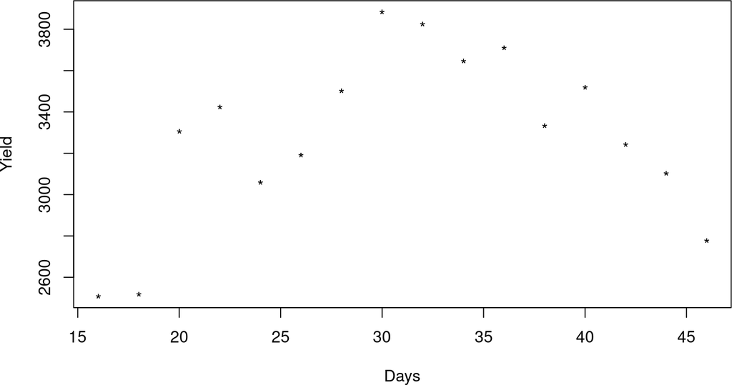

```r
 plot(rice$Days, rice$Yield, pch="*", xlab="Days", ylab="Yield")
```

```r
 rice$daymin31 <- rice$Days-31
 rice.lm <- lm(Yield ~ daymin31, data=rice)
 summary(rice.lm)
```

```
#>
#> Call:
#> lm(formula = Yield ~ daymin31, data = rice)
#>
#> Residuals:
#>     Min      1Q  Median      3Q     Max
#> -691.07 -217.65   45.85  271.77  612.14
#>
#> Coefficients:
#>             Estimate Std. Error t value Pr(>|t|)
#> (Intercept)  3283.12     103.95  31.582 2.05e-14 ***
#> daymin31       12.26      11.28   1.088    0.295
#> ---
#> Signif. codes:  0 '***' 0.001 '**' 0.01 '*' 0.05 '.' 0.1 ' ' 1
#>
#> Residual standard error: 415.8 on 14 degrees of freedom
#> Multiple R-squared:  0.07791,    Adjusted R-squared:  0.01205
#> F-statistic: 1.183 on 1 and 14 DF,  p-value: 0.2951
```

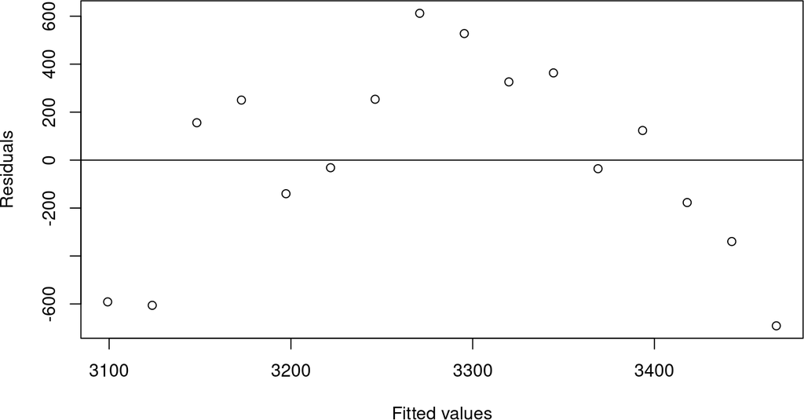

```r
 # Check the diagnostics
 plot(rice.lm$fit, rice.lm$res, xlab="Fitted values", ylab = "Residuals")
 abline(h=0)
```

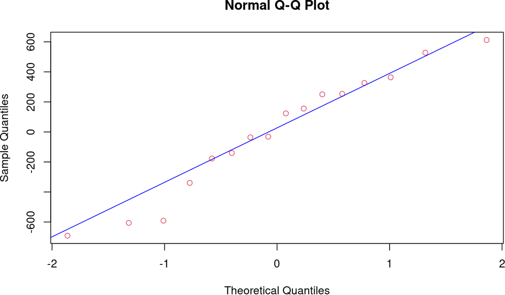

```r
 # Should be a random scatter
 # Needs a quadratic term

 qqnorm(rice.lm$res, col=2)
 qqline(rice.lm$res, col="blue")
```

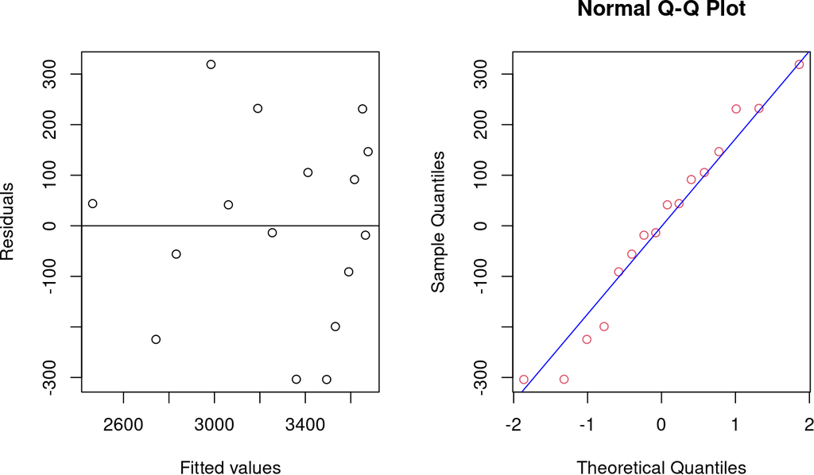

```r
 rice.lm2 <- lm(Yield ~ daymin31 + I(daymin31^2) , data=rice)
 old.par <- par(no.readonly = TRUE)
 par(mfrow=c(1, 2))
 plot(rice.lm2$fit, rice.lm2$res, xlab="Fitted values", ylab = "Residuals")
 abline(h=0)
 # Should be a random scatter
 # Much better plot!
 qqnorm(rice.lm2$res, col=2)
 qqline(rice.lm2$res, col="blue")
```

```r
 summary(rice.lm2)
```

```
#>
#> Call:
#> lm(formula = Yield ~ daymin31 + I(daymin31^2), data = rice)
#>
#> Residuals:
#>     Min      1Q  Median      3Q     Max
#> -303.96 -118.11   13.86  115.67  319.06
#>
#> Coefficients:
#>                Estimate Std. Error t value Pr(>|t|)
#> (Intercept)   3668.6682    76.7086  47.826 5.33e-16 ***
#> daymin31        12.2632     5.5286   2.218    0.045 *
#> I(daymin31^2)   -4.5358     0.6744  -6.726 1.41e-05 ***
#> ---
#> Signif. codes:  0 '***' 0.001 '**' 0.01 '*' 0.05 '.' 0.1 ' ' 1
#>
#> Residual standard error: 203.9 on 13 degrees of freedom
#> Multiple R-squared:  0.7942, Adjusted R-squared:  0.7625
#> F-statistic: 25.08 on 2 and 13 DF,  p-value: 3.452e-05
```

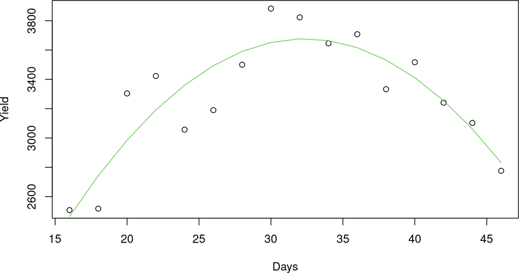

```r
 par(old.par) # par(mfrow=c(1,1))
 plot(rice$Days,  rice$Yield, xlab="Days", ylab="Yield")
 lines(rice$Days, rice.lm2$fit, lty=1, col=3)
```

```r
 rice.lm3 <- lm(Yield ~ daymin31 + I(daymin31^2)+I(daymin31^3) , data=rice)
 #check the diagnostics
 summary(rice.lm3) # Will print the summary of the fitted model
```

```
#>
#> Call:
#> lm(formula = Yield ~ daymin31 + I(daymin31^2) + I(daymin31^3),
#>     data = rice)
#>
#> Residuals:
#>     Min      1Q  Median      3Q     Max
#> -281.97 -113.21   -6.11   97.75  330.92
#>
#> Coefficients:
#>                 Estimate Std. Error t value Pr(>|t|)
#> (Intercept)   3668.66815   79.32668  46.248 6.82e-15 ***
#> daymin31        17.52493   14.49451   1.209     0.25
#> I(daymin31^2)   -4.53580    0.69743  -6.504 2.92e-05 ***
#> I(daymin31^3)   -0.03457    0.08751  -0.395     0.70
#> ---
#> Signif. codes:  0 '***' 0.001 '**' 0.01 '*' 0.05 '.' 0.1 ' ' 1
#>
#> Residual standard error: 210.8 on 12 degrees of freedom
#> Multiple R-squared:  0.7968, Adjusted R-squared:  0.746
#> F-statistic: 15.68 on 3 and 12 DF,  p-value: 0.0001876
```

```r
 #### Predict at a new value of Days=31.1465

 # Create a new data set called new
 new <- data.frame(daymin31=32.1465-31)

 a <- predict(rice.lm2, newdata=new, se.fit=TRUE)
 # Confidence interval for the mean of rice yield  at day=31.1465
 a <- predict(rice.lm2, newdata=new, interval="confidence")
 a
```

```
#>        fit      lwr      upr
#> 1 3676.766 3511.904 3841.628
```

```r
 #          fit      lwr      upr
 # [1,] 3676.766 3511.904 3841.628
 # Prediction interval for a future yield at day=31.1465
 b <- predict(rice.lm2, newdata=new, interval="prediction")
 b
```

```
#>        fit      lwr      upr
#> 1 3676.766 3206.461 4147.071
```

```r
 # fit      lwr      upr
 #[1,] 3676.766 3206.461 4147.071
```

## 2.15 `wgain`: Weight gain of students starting college

This contains weight gain data from 68 first year students during their first 12 weeks in college. Source: Levitsky {} (2004). (Levitsky and Mrdjenovic 2004) This data set has been used to illustrate confidence intervals and $t$-tests  
in part I of the book Sahu (2024).

```r
summary(wgain)
```

```
#>     student         initial          final
#>  Min.   : 1.00   Min.   :42.64   Min.   : 43.54
#>  1st Qu.:17.75   1st Qu.:53.86   1st Qu.: 54.32
#>  Median :34.50   Median :60.78   Median : 60.78
#>  Mean   :34.50   Mean   :61.72   Mean   : 62.59
#>  3rd Qu.:51.25   3rd Qu.:68.04   3rd Qu.: 68.49
#>  Max.   :68.00   Max.   :99.79   Max.   :101.60
```

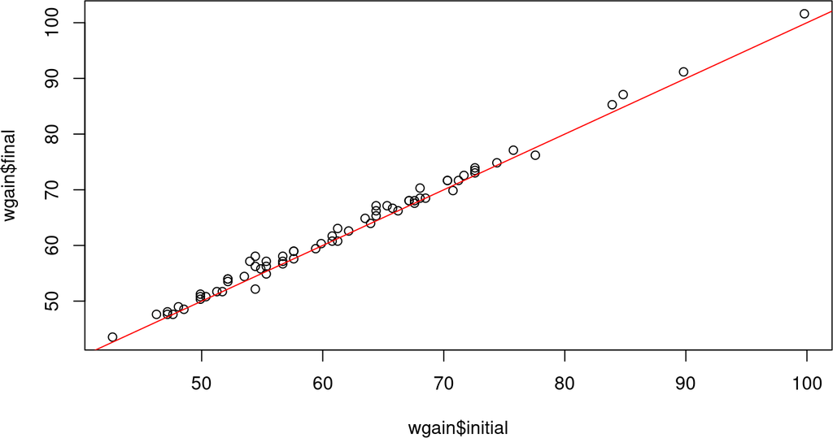

```r
plot(wgain$initial, wgain$final)
abline(0, 1, col="red")
```

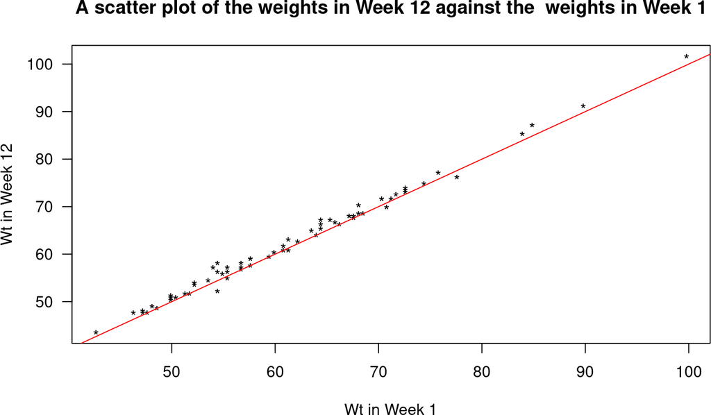

```r
plot(wgain$initial, wgain$final, xlab="Wt in Week 1", ylab="Wt in Week 12",
     pch="*", las=1)
abline(0, 1, col="red")
title("A scatter plot of the weights in Week 12 against the  weights in Week 1")
```

```r
# 95% Confidence interval for mean weight gain
x <- wgain$final - wgain$initial
mean(x) + c(-1, 1) * qt(0.975, df=67) * sqrt(var(x)/68)
```

```
#> [1] 0.6334959 1.1008265
```

```r
# t-test to test the mean difference equals 0
t.test(x)
```

```
#>
#>  One Sample t-test
#>
#> data:  x
#> t = 7.4074, df = 67, p-value = 2.813e-10
#> alternative hypothesis: true mean is not equal to 0
#> 95 percent confidence interval:
#>  0.6334959 1.1008265
#> sample estimates:
#> mean of x
#> 0.8671612
```

# 3 Illustrated R functions

## 3.1 The butterfly function

This function draws a butterfly as on the front cover of the book. This is a plot obtained as follows. Initially a sequence of angles denoted by $\theta$ is chosen in the range 0 to 24$\pi$. Then, we specify two parameters $a$ and $b$ and evaluate the following equations. The illustrations show the effect of these two parameters on the shape of the resulting plot obtained by plotting $x-y$ pairs. Successive points on the plot are joined by lines.
$$\begin{equation}
r = \exp(\cos(\theta)) - a \cos(b \, \theta) + \sin\left(\frac{\theta}{12}\right) \\
x = r \sin(\theta) \\
y = -r \cos(\theta)
\end{equation}$$

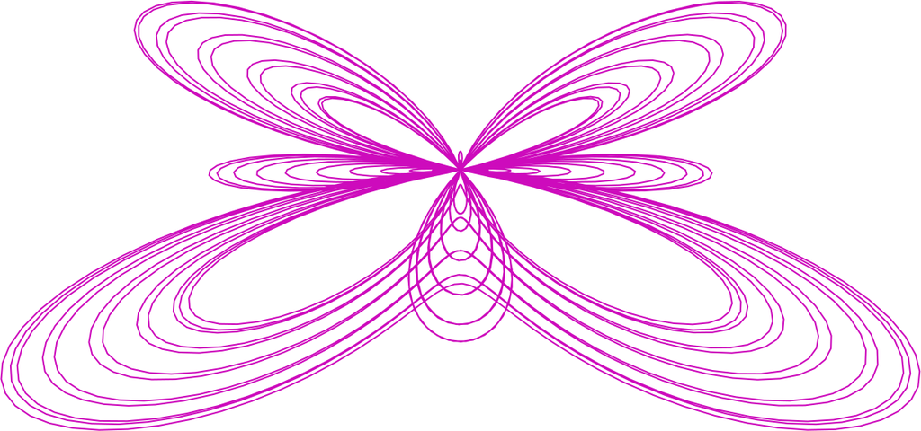

```r
butterfly(color = 6)
```

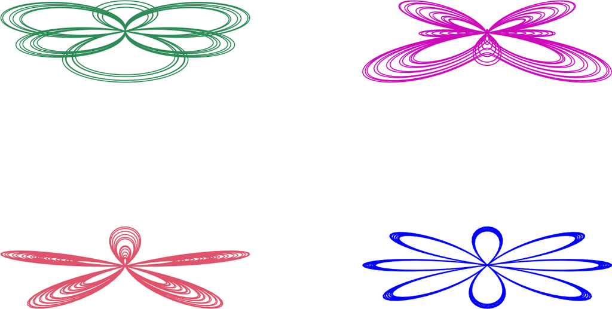

```r
old.par <- par(no.readonly = TRUE)
par(mfrow=c(2, 2))
butterfly(a=10, b=1.5, color = "seagreen")
butterfly(color = 6)
butterfly(a=5, b=5, color=2)
butterfly(a=20, b=4, color = "blue")
```

```r
par(old.par) # par(mfrow=c(1, 1))
```

## 3.2 Simulation of the Monty Hall game

[figure not shown]

Figure 2: Monty Hall game

The other parameters are $N$: How many games to play, defaults to 1000 and `print_games`, which is a logical argument that tells whether to print the results of each of the $N$ games. Here are three illustrations of the games.

```r
monty("stay", print_games = FALSE)
monty("switch", print_games = FALSE)
monty("random", print_games = FALSE)
```

[output not shown]

## 3.3 Functions illustrating the Central Limit Theorem (CLT)

There are two functions illustrating the CLT. The first one ‘?see_the_clt_for_Bernoulli’ simulates `nrep=10000` samples of size `nsize=10` with probability of success $p=0.8$ by default. It then finds the means of the `nrep` samples and standardises the means by subtracting the overall mean and dividing by the sample standard deviation. It then draws a histogram of the sample means and superimposes the theoretical density of the standard normal distribution. The histogram will closely resemble the density of the standard normal distribution if the CLT approximation is good. The quality of the approximation depends on the sample size `nsize`. This can be observed from the illustrations provided below.

```r
a <- see_the_clt_for_Bernoulli()
```

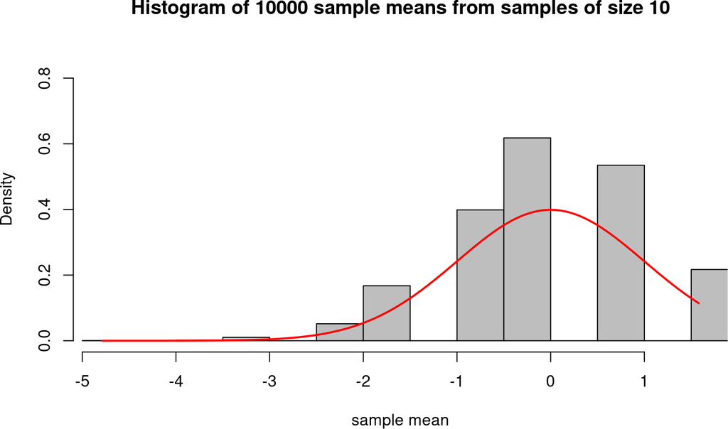

```r
old.par <- par(no.readonly = TRUE)
par(mfrow=c(2, 3))
a30 <- see_the_clt_for_Bernoulli(nsize=30)
a50 <- see_the_clt_for_Bernoulli(nsize=50)
a100 <- see_the_clt_for_Bernoulli(nsize=100)
a500 <- see_the_clt_for_Bernoulli(nsize=500)
a1000 <- see_the_clt_for_Bernoulli(nsize=1000)
a5000 <- see_the_clt_for_Bernoulli(nsize=5000)
```

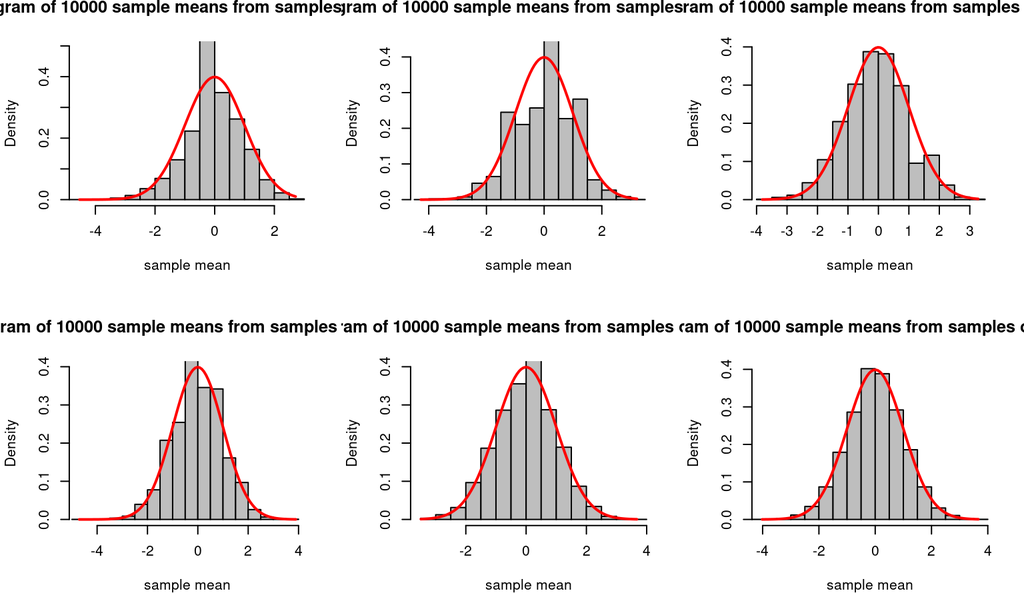

```r
par(old.par)
```

The second function `?see_the_clt_for_uniform` demonstrates the CLT for sampling from the uniform distribution in the interval (0,1). As in the previous function for the Bernoulli distribution, this also takes two similar arguments and behaves very similarly as demonstrated below. But the sampling is done from the uniform distribution.

```r
a <- see_the_clt_for_uniform()
```

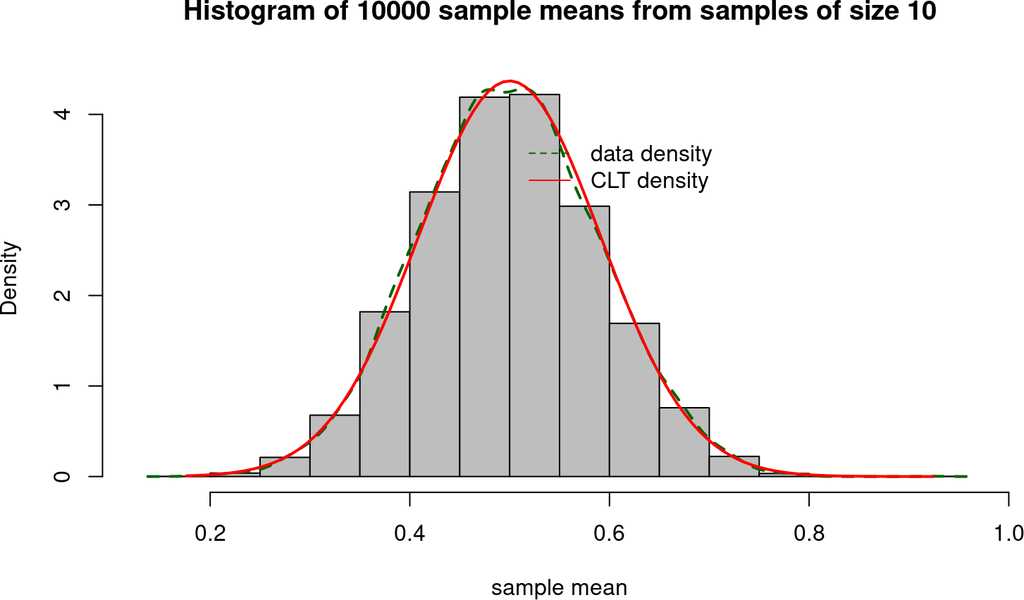

```r
old.par <- par(no.readonly = TRUE)
par(mfrow=c(2, 3))
a1 <- see_the_clt_for_uniform(nsize=1)
a2 <- see_the_clt_for_uniform(nsize=2)
a3 <- see_the_clt_for_uniform(nsize=5)
a4 <- see_the_clt_for_uniform(nsize=10)
a5 <- see_the_clt_for_uniform(nsize=20)
a6 <- see_the_clt_for_uniform(nsize=50)
```

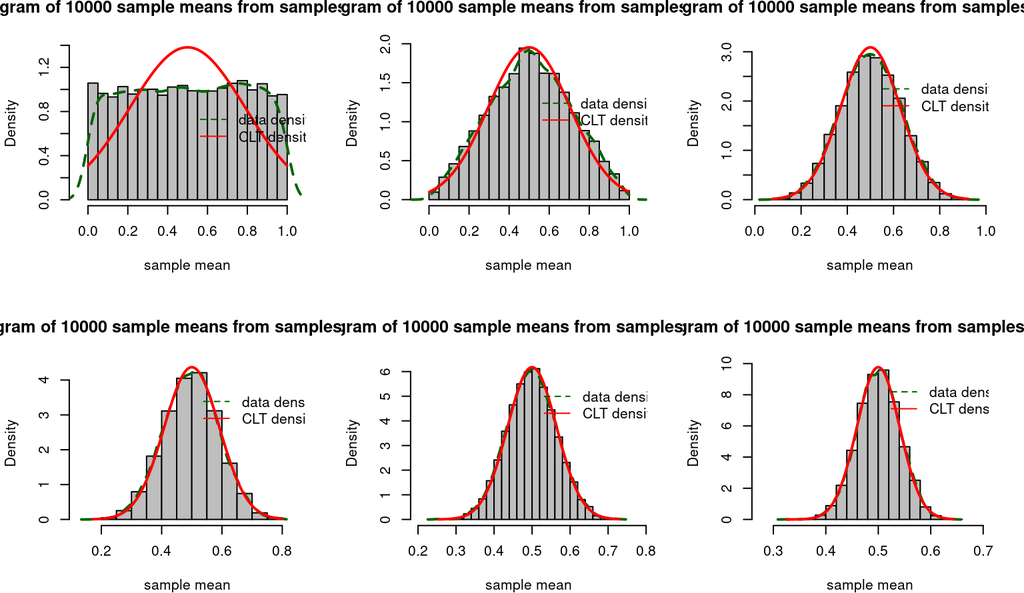

```r
par(old.par)
ybars <- see_the_clt_for_uniform(nsize=12)
```

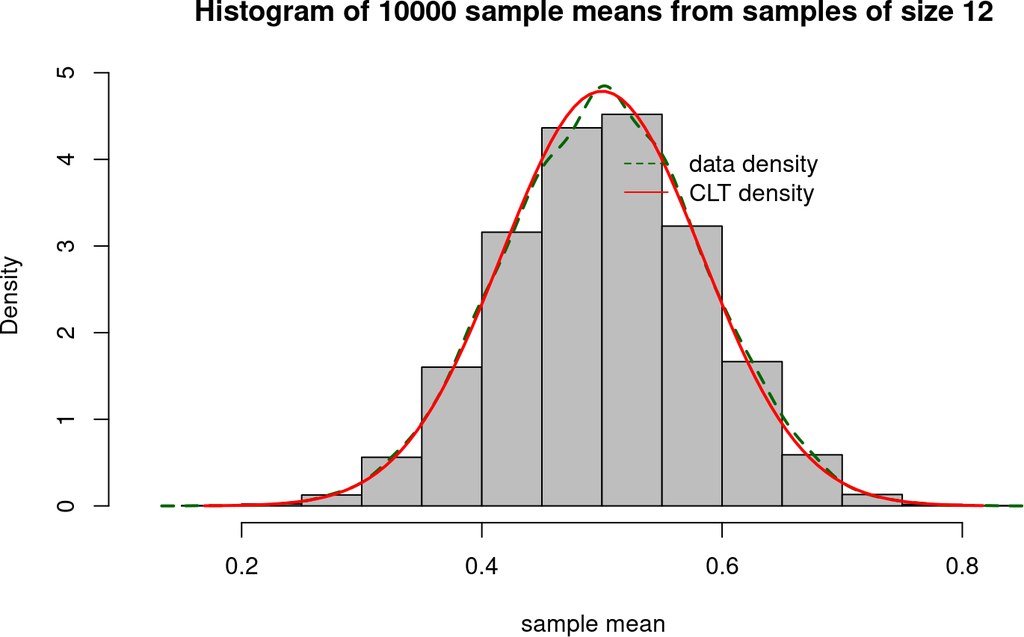

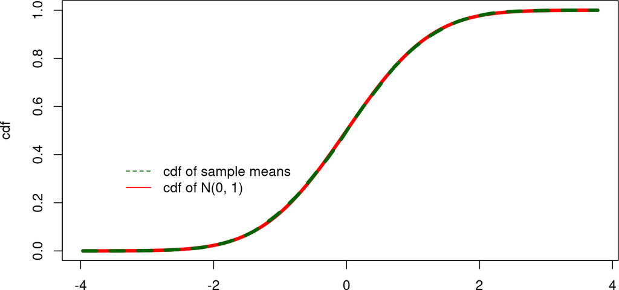

```r
zbars <- (ybars - mean(ybars))/sd(ybars)
k <- 100
u <- seq(from=min(zbars), to= max(zbars), length=k)
ecdf <-  rep(NA, k)
for(i in 1:k) ecdf[i] <- length(zbars[zbars<u[i]])/length(zbars)
tcdf <- pnorm(u)
plot(u, tcdf, type="l", col="red", lwd=4, xlab="", ylab="cdf")
lines(u, ecdf, lty=2, col="darkgreen", lwd=4)
symb <- c("cdf of sample means", "cdf of N(0, 1)")
legend(x=-3.5, y=0.4, legend = symb, lty = c(2, 1),
col = c("darkgreen","red"), bty="n")
```

This function also provides a plot of the estimated cumulative density function (cdf) of the standarised sample means and superimposes the cdf of the standard normal distribution. The CLT states that these cdf’s will be very close to each other as the sample size $n \to \infty$.

## 3.4 Functions illustrating the Weak Law of Large Numbers (WLLN)

The function `?see_the_wlln_for_uniform` illustrates the WLLN for sampling from the uniform distribution in the interval (0, 1). Similar to the two functions demonstrating the CLT, this function takes two arguments `nsize` for sample size and `nrep` for number of replications. The function draws the histogram of the replicated sample means and draws an estimated density function of the samples. The below illustration shows that the estimated density gets more peaked as the sample size $n$ increases. The WLLN says that the estimated density will gradually become just a spike as $n \to \infty$.

```r
a1 <- see_the_wlln_for_uniform(nsize=1, nrep=50000)
```

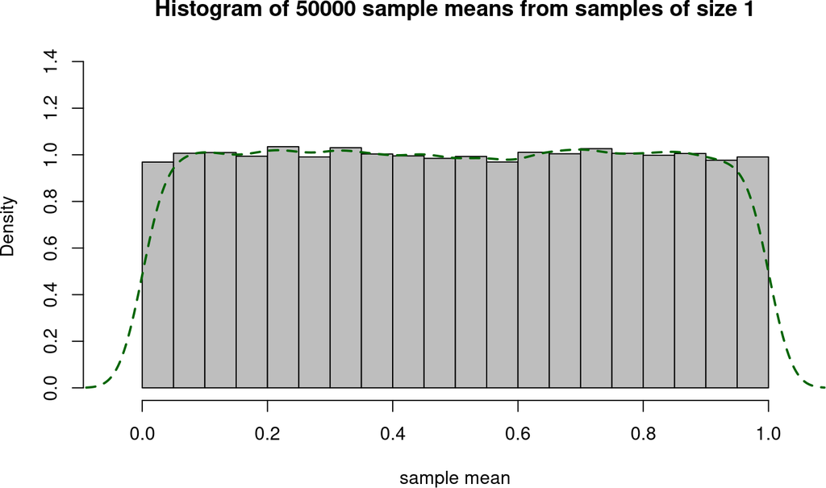

```r
a2 <- see_the_wlln_for_uniform(nsize=10, nrep=50000)
```

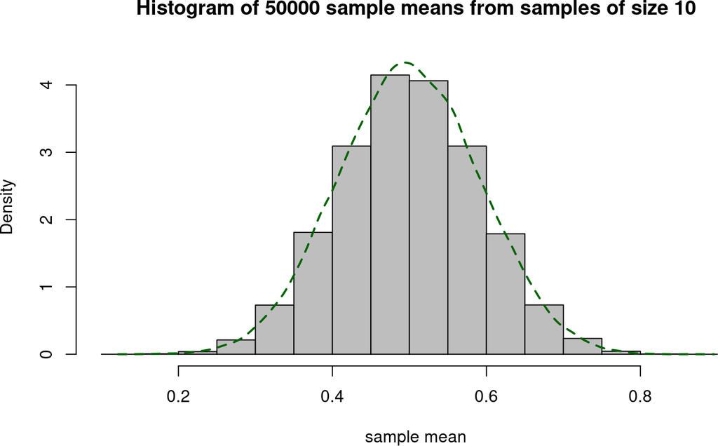

```r
a3 <- see_the_wlln_for_uniform(nsize=50, nrep=50000)
```

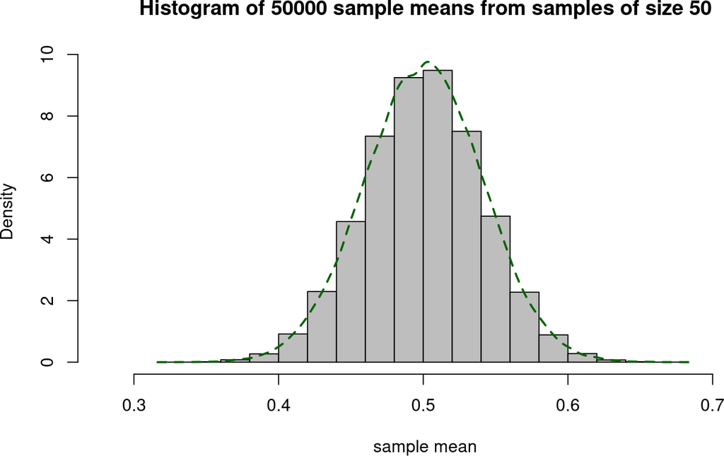

```r
a4 <- see_the_wlln_for_uniform(nsize=100, nrep=50000)
```

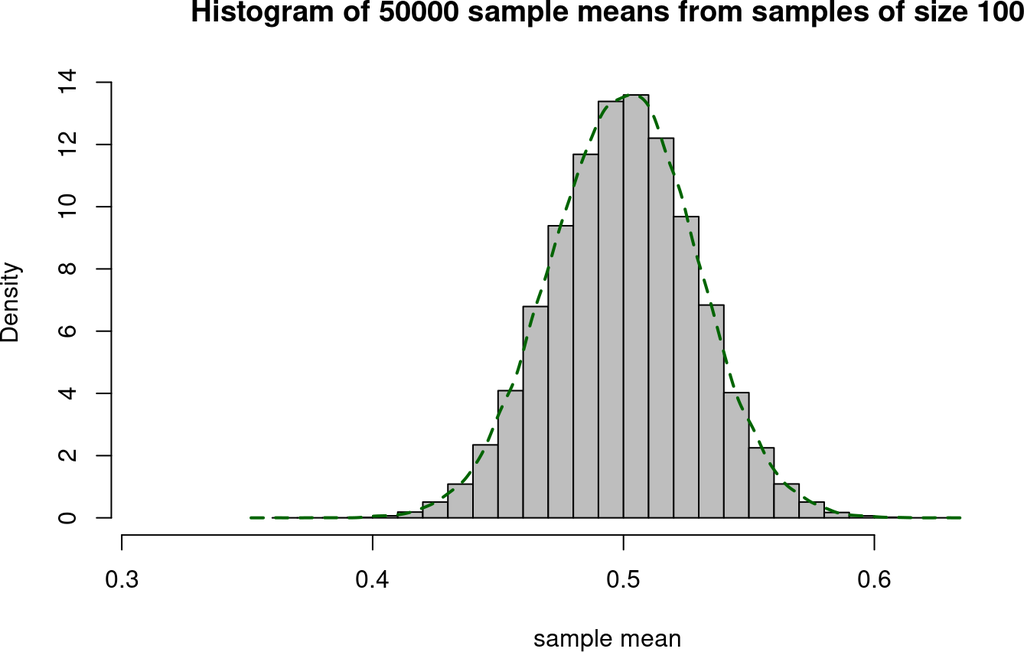

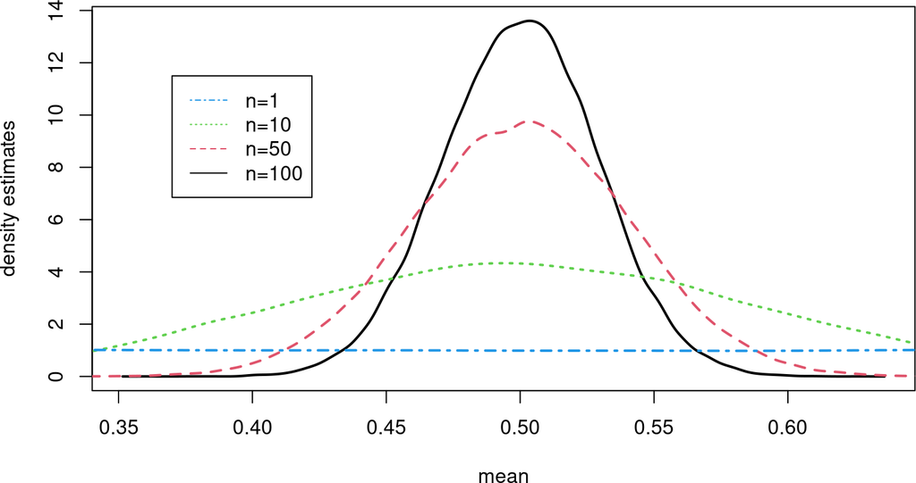

```r
plot(a4, type="l", lwd=2, ylim=range(c(a1$y, a2$y, a3$y, a4$y)), col=1,
lty=1, xlab="mean", ylab="density estimates")
lines(a3, type="l", lwd=2, col=2, lty=2)
lines(a2, type="l", lwd=2, col=3, lty=3)
lines(a1, type="l", lwd=2, col=4, lty=4)
symb <- c("n=1", "n=10", "n=50", "n=100")
legend(x=0.37, y=11.5, legend = symb, lty =4:1, col = 4:1)
```

# 4 Discussion

The data sets included in this package and discussed in this vignette can be used in teaching and learning of introductory probability, statistics, `R` for data-based sciences with or without reading the book by the same author, (Sahu 2024). So that a beginner reader can understand the methods, and also being introductory in nature, this package has used very basic `R` commands and scripts throughout. But the package has illustrated the use of the advanced graphics package *ggplot2* and function writing through the `butterfly` function. However, *ipsRdbs* does not intentionally teach R programming and does not expect the users to be proficient in adopting those techniques in their own data analysis and processing. It has been purposefully designed this way to interest the reader to further learn and use more advanced graphics and data manipulation and analysis capabilities of R.

# References

Bal, S., and T. P. Ojha. 1975. “Determination of Biological Maturity and Effect of Harvesting and Drying Conditions on Milling Quality of Paddy.” *Journal of Agricultural Engineering Research* 20 (4): 353–61. https://doi.org/https://doi.org/10.1016/0021-8634(75)90072-4.

Chivers, Corey. 2012. “Monty Hall by Simulation in r.” *Posted in Probability, Rstats, Teaching*.

David J. Hand, K. McConway, Fergus Daly, and E. Ostrowski. 1993. *A Handbook of Small Data Sets*. London: CRC Press.

Levitsky, Halbmaier, David, and Gordana. Mrdjenovic. 2004. “A Model for the Study of the Epidemic of Obesity.” *International Journal of Obesity and Related Metabolic Disorders : Journal of the International Association for the Study of Obesity* 28: 1435–42. https://doi.org/10.1038/sj.ijo.0802776.

Lindenmayer, Viggers, D. B., and C. F. Donnelly. 1995. “Morphological Variation Among Columns of the Mountain Brushtail Possum, Trichosurus Caninus Ogilby (Phalangeridae: Marsupiala).” *Australian Journal of Zoology* 43: 449–58.

Nettleship, David N. 1972. “Breeding Success of the Common Puffin (Fratercula Arctica l.) on Different Habitats at Great Island, Newfoundland.” *Ecological Monographs* 42: 239–68.

Sahu, Sujit K. 2024. *Introduction to Probability, Statistics and r for Data-Based Sciences*. 1st ed. Cham, Switzerland: Springer Nature Switzerland AG.

Shaw, L. P, and L. F. Shaw. 2019. “The Flying Bomb and the Actuary.” *Significance Magazine* 16: 12–17.